# Project-Ensemble Techniques - Term Deposit Subscription Prediction_06.19.2020

## Problem statement (Term Deposit Sale)

## Goal

Using the data collected from existing customers, build a model that will help the marketing team identify potential customers who are relatively more likely to subscribe term deposit and thus increase their hit ratio.

### Resources Available

The historical data for this project is available in file https://archive.ics.uci.edu/ml/datasets/Bank+Marketing

### Attribute information

#### Input variables:

#### Bank client data:

1. age: Continuous feature
2. job: Type of job (management, technician, entrepreneur, blue-collar, etc.)
3. marital: marital status (married, single, divorced)
4. education: education level (primary, secondary, tertiary)
5. default: has credit in default?
6. housing: has housing loan?
7. loan: has personal loan?
8. balance in account

#### Related to previous contact:

1. contact: contact communication type
2. month: last contact month of year
3. day: last contact day of the month
4. duration: last contact duration, in seconds*

#### Other attributes:

1. campaign: number of contacts performed during this campaign and for this client
2. pdays: number of days that passed by after the client was last contacted from a previous campaign (-1 tells us the person has not been contacted or contact period is beyond 900 days)
3. previous: number of contacts performed before this campaign and for this client
4. poutcome: outcome of the previous marketing campaign

#### Output variable (desired target):

1. Target: Tell us has the client subscribed a term deposit. (Yes, No)

## https://github.com/GreatLearningAIML1/gl-pgp-aiml-uta-intl-apr20-SubratMuruni.git

## Deliverable – 1 (Exploratory data quality report reflecting the following) – (20 marks)

```python
# Import all essential python libraries

import numpy as np # Importing Numpy
import pandas as pd # Importing Pandas
import scipy.stats as stats # Importing Scipy for statistical operations
import matplotlib.pyplot as plt # Importing Matplotlib
import seaborn as sns # Importing Seaborn
sns.set(color_codes = True) # setting the background of the visualization graph
%matplotlib inline
import warnings
warnings.filterwarnings('ignore')
from sklearn.model_selection import train_test_split
from sklearn.tree import DecisionTreeClassifier
from sklearn import tree
from sklearn import metrics
from IPython.display import Image
from os import system
from sklearn.ensemble import BaggingClassifier
from sklearn.ensemble import AdaBoostClassifier
from sklearn.ensemble import GradientBoostingClassifier
from sklearn.ensemble import RandomForestClassifier
```

### 1.1. Univariate analysis (12 marks)

a. Univariate analysis – data types and description of the independent attributes which should include (name, meaning, range of values observed, central values (mean and median), standard deviation and quartiles, analysis of the body of distributions / tails, missing values, outliers.

b. Strategies to address the different data challenges such as data pollution, outlier’s treatment and missing values treatment.  
c. Please provide comments in jupyter notebook regarding the steps you take and insights drawn from the plots.

**1.1.1 General characteristic of the dataset**

```python
# read the dataset into a dataframe

dfTermDeposit = pd.read_csv('/Users/subratmuruni/desktop/Data Science/Projects_Assignments/Project_dataset/bank-full.csv')
```

```python
# reading the first 5 rows of the dataset

dfTermDeposit.head()
```

|  | age | job | marital | education | default | balance | housing | loan | contact | day | month | duration | campaign | pdays | previous | poutcome | Target |
| --- | --- | --- | --- | --- | --- | --- | --- | --- | --- | --- | --- | --- | --- | --- | --- | --- | --- |
| 0 | 58 | management | married | tertiary | no | 2143 | yes | no | unknown | 5 | may | 261 | 1 | -1 | 0 | unknown | no |
| 1 | 44 | technician | single | secondary | no | 29 | yes | no | unknown | 5 | may | 151 | 1 | -1 | 0 | unknown | no |
| 2 | 33 | entrepreneur | married | secondary | no | 2 | yes | yes | unknown | 5 | may | 76 | 1 | -1 | 0 | unknown | no |
| 3 | 47 | blue-collar | married | unknown | no | 1506 | yes | no | unknown | 5 | may | 92 | 1 | -1 | 0 | unknown | no |
| 4 | 33 | unknown | single | unknown | no | 1 | no | no | unknown | 5 | may | 198 | 1 | -1 | 0 | unknown | no |

```python
# reading the last 5 rows of the dataset

dfTermDeposit.tail()
```

|  | age | job | marital | education | default | balance | housing | loan | contact | day | month | duration | campaign | pdays | previous | poutcome | Target |
| --- | --- | --- | --- | --- | --- | --- | --- | --- | --- | --- | --- | --- | --- | --- | --- | --- | --- |
| 45206 | 51 | technician | married | tertiary | no | 825 | no | no | cellular | 17 | nov | 977 | 3 | -1 | 0 | unknown | yes |
| 45207 | 71 | retired | divorced | primary | no | 1729 | no | no | cellular | 17 | nov | 456 | 2 | -1 | 0 | unknown | yes |
| 45208 | 72 | retired | married | secondary | no | 5715 | no | no | cellular | 17 | nov | 1127 | 5 | 184 | 3 | success | yes |
| 45209 | 57 | blue-collar | married | secondary | no | 668 | no | no | telephone | 17 | nov | 508 | 4 | -1 | 0 | unknown | no |
| 45210 | 37 | entrepreneur | married | secondary | no | 2971 | no | no | cellular | 17 | nov | 361 | 2 | 188 | 11 | other | no |

```python
# finding the rows and columns of the dataset

dfTermDeposit.shape # dataset has 45211 rows and 17 columns
```

```
(45211, 17)
```

```python
# columns of the dataset

dfTermDeposit.columns
```

```
Index(['age', 'job', 'marital', 'education', 'default', 'balance', 'housing',
       'loan', 'contact', 'day', 'month', 'duration', 'campaign', 'pdays',
       'previous', 'poutcome', 'Target'],
      dtype='object')
```

```python
# information of the dataset with regards to columns, count and datatype

dfTermDeposit.info() # indicates 7 int datatype columns and 10 object(string) type columns
```

```
<class 'pandas.core.frame.DataFrame'>
RangeIndex: 45211 entries, 0 to 45210
Data columns (total 17 columns):
 #   Column     Non-Null Count  Dtype
---  ------     --------------  -----
 0   age        45211 non-null  int64
 1   job        45211 non-null  object
 2   marital    45211 non-null  object
 3   education  45211 non-null  object
 4   default    45211 non-null  object
 5   balance    45211 non-null  int64
 6   housing    45211 non-null  object
 7   loan       45211 non-null  object
 8   contact    45211 non-null  object
 9   day        45211 non-null  int64
 10  month      45211 non-null  object
 11  duration   45211 non-null  int64
 12  campaign   45211 non-null  int64
 13  pdays      45211 non-null  int64
 14  previous   45211 non-null  int64
 15  poutcome   45211 non-null  object
 16  Target     45211 non-null  object
dtypes: int64(7), object(10)
memory usage: 5.9+ MB
```

**1.1.2 Datatype, Central Value, IQR, standard Deviation**

```python
# datatype of the columns of the dataset

dfTermDeposit.dtypes # there are 10 columns with datatype as object.We may have to change the datatype for modelling
```

```
age           int64
job          object
marital      object
education    object
default      object
balance       int64
housing      object
loan         object
contact      object
day           int64
month        object
duration      int64
campaign      int64
pdays         int64
previous      int64
poutcome     object
Target       object
dtype: object
```

```python
# finding the mean of the columns of the dataset

dfTermDeposit.mean() # provides mean of the continuous variables
```

```
age           40.936210
balance     1362.272058
day           15.806419
duration     258.163080
campaign       2.763841
pdays         40.197828
previous       0.580323
dtype: float64
```

```python
# finding the median of the columns of the dataset

dfTermDeposit.median() # provides median of the continuous variables
```

```
age          39.0
balance     448.0
day          16.0
duration    180.0
campaign      2.0
pdays        -1.0
previous      0.0
dtype: float64
```

```python
# finding the mode of the columns of the dataset

dfTermDeposit.mode() # provides mode of the continuous and categorical variables
```

|  | age | job | marital | education | default | balance | housing | loan | contact | day | month | duration | campaign | pdays | previous | poutcome | Target |
| --- | --- | --- | --- | --- | --- | --- | --- | --- | --- | --- | --- | --- | --- | --- | --- | --- | --- |
| 0 | 32 | blue-collar | married | secondary | no | 0 | yes | no | cellular | 20 | may | 124 | 1 | -1 | 0 | unknown | no |

```python
# finding the standard deviation of the continuous variables

dfTermDeposit.std()
```

```
age           10.618762
balance     3044.765829
day            8.322476
duration     257.527812
campaign       3.098021
pdays        100.128746
previous       2.303441
dtype: float64
```

```python
# finding interquartile range of the dataset

IQR = dfTermDeposit.quantile(0.75)- dfTermDeposit.quantile(0.25)
IQR # gives the IQR of continuous variables
```

```
age           15.0
balance     1356.0
day           13.0
duration     216.0
campaign       2.0
pdays          0.0
previous       0.0
dtype: float64
```

**1.1.3 Missing values, Null values and incorrect imputation**

```python
# checking the missing values/null in the dataset

dfTermDeposit.isnull().sum() # there are no null values in the dataset
```

```
age          0
job          0
marital      0
education    0
default      0
balance      0
housing      0
loan         0
contact      0
day          0
month        0
duration     0
campaign     0
pdays        0
previous     0
poutcome     0
Target       0
dtype: int64
```

```python
# finding null values in the dataset

dfTermDeposit.isnull().any() # all columns indicate false which means no missing values
```

```
age          False
job          False
marital      False
education    False
default      False
balance      False
housing      False
loan         False
contact      False
day          False
month        False
duration     False
campaign     False
pdays        False
previous     False
poutcome     False
Target       False
dtype: bool
```

```python
# checking for values that are Na

dfTermDeposit.isna().sum() # there are no values as Na or NaN
```

```
age          0
job          0
marital      0
education    0
default      0
balance      0
housing      0
loan         0
contact      0
day          0
month        0
duration     0
campaign     0
pdays        0
previous     0
poutcome     0
Target       0
dtype: int64
```

```python
# finding Na or improper values in the dataset

dfTermDeposit.isna().any() # false indicates no Na or NaN values in the dataset
```

```
age          False
job          False
marital      False
education    False
default      False
balance      False
housing      False
loan         False
contact      False
day          False
month        False
duration     False
campaign     False
pdays        False
previous     False
poutcome     False
Target       False
dtype: bool
```

```python
# find duplicates in the dataset

dfTermDeposit.duplicated().sum() # there are no duplicated rows in the dataset
```

```
0
```

```python
# find whether all values in columns that are not designated as object datatype are real or not

dfTermDeposit[~dfTermDeposit[['age', 'balance', 'day', 'duration', 'campaign', 'pdays','previous']]
              .applymap(np.isreal).all(1)] # results show that all are real values

# this doesn't include the categorical/object datatype columns
```

|  | age | job | marital | education | default | balance | housing | loan | contact | day | month | duration | campaign | pdays | previous | poutcome | Target |
| --- | --- | --- | --- | --- | --- | --- | --- | --- | --- | --- | --- | --- | --- | --- | --- | --- | --- |

```python
# finding the unique values of variables

dfTermDeposit.nunique() # indicates that binning can be done on balance, duration and pdays for smoothening data
```

```
age            77
job            12
marital         3
education       4
default         2
balance      7168
housing         2
loan            2
contact         3
day            31
month          12
duration     1573
campaign       48
pdays         559
previous       41
poutcome        4
Target          2
dtype: int64
```

```python
# finding the value counts of categorical variables
# this will help us in identifying how to handle these features or columns

print(dfTermDeposit['job'].value_counts()) # nominal categorial variable
print()
print(dfTermDeposit['marital'].value_counts()) # can be treated as ordinal categorical variable
print()
print(dfTermDeposit['education'].value_counts()) # can be treated as ordinal categorical variable
print()
print(dfTermDeposit['default'].value_counts()) # binary categorical variable
print()
print(dfTermDeposit['housing'].value_counts()) # binary categorical variable
print()
print(dfTermDeposit['loan'].value_counts()) # binary categorical variable
print()
print(dfTermDeposit['contact'].value_counts()) # nominal categorical variable
print()
print(dfTermDeposit['month'].value_counts()) # can be treated as ordinal categorical variable
print()
print(dfTermDeposit['poutcome'].value_counts()) # binary categorical variable
print()
print(dfTermDeposit['Target'].value_counts())# binary categorical variable
```

```
blue-collar      9732
management       9458
technician       7597
admin.           5171
services         4154
retired          2264
self-employed    1579
entrepreneur     1487
unemployed       1303
housemaid        1240
student           938
unknown           288
Name: job, dtype: int64

married     27214
single      12790
divorced     5207
Name: marital, dtype: int64

secondary    23202
tertiary     13301
primary       6851
unknown       1857
Name: education, dtype: int64

no     44396
yes      815
Name: default, dtype: int64

yes    25130
no     20081
Name: housing, dtype: int64

no     37967
yes     7244
Name: loan, dtype: int64

cellular     29285
unknown      13020
telephone     2906
```

[output cut: 10 more lines]

```
oct      738
sep      579
mar      477
dec      214
Name: month, dtype: int64

unknown    36959
failure     4901
other       1840
success     1511
Name: poutcome, dtype: int64

no     39922
yes     5289
Name: Target, dtype: int64
```

```python
# capturing the value count of categorical features in a dataframe

cols = ['job','marital', 'education','default','housing','loan','contact', 'month', 'poutcome','Target']

output = []

for index, feature in enumerate(cols):
    output.append(dfTermDeposit[feature].value_counts())

pd.DataFrame(output)
```

|  | blue-collar | management | technician | admin. | services | retired | self-employed | entrepreneur | unemployed | housemaid | ... | apr | feb | jan | oct | sep | mar | dec | failure | other | success |
| --- | --- | --- | --- | --- | --- | --- | --- | --- | --- | --- | --- | --- | --- | --- | --- | --- | --- | --- | --- | --- | --- |
| job | 9732.0 | 9458.0 | 7597.0 | 5171.0 | 4154.0 | 2264.0 | 1579.0 | 1487.0 | 1303.0 | 1240.0 | ... | NaN | NaN | NaN | NaN | NaN | NaN | NaN | NaN | NaN | NaN |
| marital | NaN | NaN | NaN | NaN | NaN | NaN | NaN | NaN | NaN | NaN | ... | NaN | NaN | NaN | NaN | NaN | NaN | NaN | NaN | NaN | NaN |
| education | NaN | NaN | NaN | NaN | NaN | NaN | NaN | NaN | NaN | NaN | ... | NaN | NaN | NaN | NaN | NaN | NaN | NaN | NaN | NaN | NaN |
| default | NaN | NaN | NaN | NaN | NaN | NaN | NaN | NaN | NaN | NaN | ... | NaN | NaN | NaN | NaN | NaN | NaN | NaN | NaN | NaN | NaN |
| housing | NaN | NaN | NaN | NaN | NaN | NaN | NaN | NaN | NaN | NaN | ... | NaN | NaN | NaN | NaN | NaN | NaN | NaN | NaN | NaN | NaN |
| loan | NaN | NaN | NaN | NaN | NaN | NaN | NaN | NaN | NaN | NaN | ... | NaN | NaN | NaN | NaN | NaN | NaN | NaN | NaN | NaN | NaN |
| contact | NaN | NaN | NaN | NaN | NaN | NaN | NaN | NaN | NaN | NaN | ... | NaN | NaN | NaN | NaN | NaN | NaN | NaN | NaN | NaN | NaN |
| month | NaN | NaN | NaN | NaN | NaN | NaN | NaN | NaN | NaN | NaN | ... | 2932.0 | 2649.0 | 1403.0 | 738.0 | 579.0 | 477.0 | 214.0 | NaN | NaN | NaN |
| poutcome | NaN | NaN | NaN | NaN | NaN | NaN | NaN | NaN | NaN | NaN | ... | NaN | NaN | NaN | NaN | NaN | NaN | NaN | 4901.0 | 1840.0 | 1511.0 |
| Target | NaN | NaN | NaN | NaN | NaN | NaN | NaN | NaN | NaN | NaN | ... | NaN | NaN | NaN | NaN | NaN | NaN | NaN | NaN | NaN | NaN |

10 rows × 37 columns

```python
# applying the describe function on the dataframe

dfTermDeposit.describe() # by default it applies to all the continuous variables.

# we will revisit the describe function after data clean up.
```

|  | age | balance | day | duration | campaign | pdays | previous |
| --- | --- | --- | --- | --- | --- | --- | --- |
| count | 45211.000000 | 45211.000000 | 45211.000000 | 45211.000000 | 45211.000000 | 45211.000000 | 45211.000000 |
| mean | 40.936210 | 1362.272058 | 15.806419 | 258.163080 | 2.763841 | 40.197828 | 0.580323 |
| std | 10.618762 | 3044.765829 | 8.322476 | 257.527812 | 3.098021 | 100.128746 | 2.303441 |
| min | 18.000000 | -8019.000000 | 1.000000 | 0.000000 | 1.000000 | -1.000000 | 0.000000 |
| 25% | 33.000000 | 72.000000 | 8.000000 | 103.000000 | 1.000000 | -1.000000 | 0.000000 |
| 50% | 39.000000 | 448.000000 | 16.000000 | 180.000000 | 2.000000 | -1.000000 | 0.000000 |
| 75% | 48.000000 | 1428.000000 | 21.000000 | 319.000000 | 3.000000 | -1.000000 | 0.000000 |
| max | 95.000000 | 102127.000000 | 31.000000 | 4918.000000 | 63.000000 | 871.000000 | 275.000000 |

```python
# check the skewness of the continuous variables

dfTermDeposit.skew()
```

```
age          0.684818
balance      8.360308
day          0.093079
duration     3.144318
campaign     4.898650
pdays        2.615715
previous    41.846454
dtype: float64
```

```python
# creating dataframe with pdays = -1 and previous = 0

df_2 = dfTermDeposit[(dfTermDeposit['pdays']== -1)
                               & (dfTermDeposit['previous']== 0)]
```

```python
# checking the row count of the dataframe produced

df_2['pdays'].value_counts()
```

```
-1    36954
Name: pdays, dtype: int64
```

**1.1.4 Age**

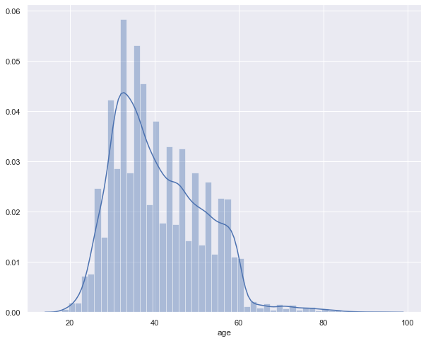

```python
# plotting the histogram for age

plt.figure(figsize = (10,8))
sns.distplot(dfTermDeposit['age'],kde=True);
plt.show() # the data distribution is slightly right skewed
```

```python
# statistics for the feature

dfTermDeposit['age'].describe()
```

```
count    45211.000000
mean        40.936210
std         10.618762
min         18.000000
25%         33.000000
50%         39.000000
75%         48.000000
max         95.000000
Name: age, dtype: float64
```

**1.1.5 Job**

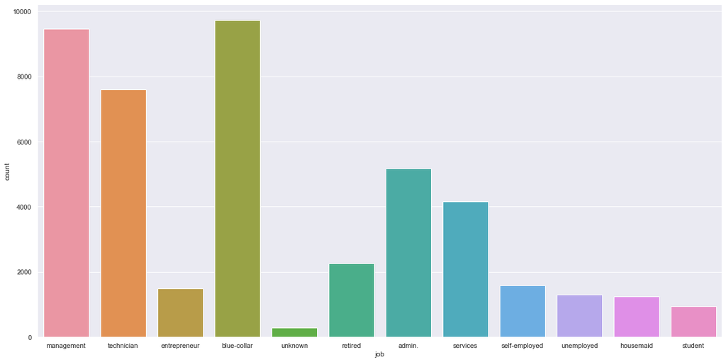

```python
# plotting the count plot for the job

plt.figure(figsize=(20,10))
sns.countplot(dfTermDeposit['job']);
plt.show() # maximum observations are between blue-collar, management and technican values
```

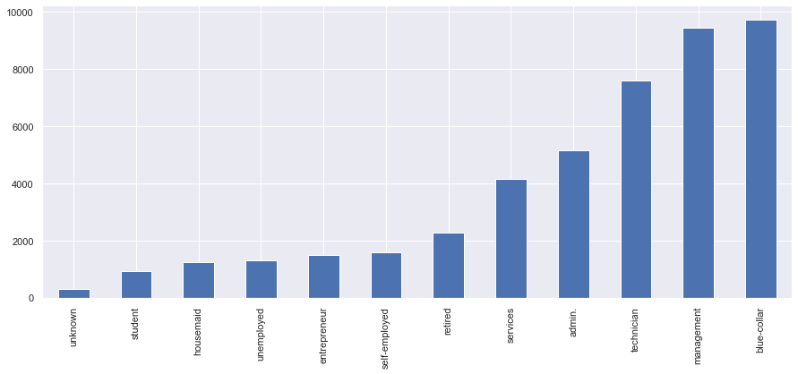

```python
# ordering the value count for job in ascending order

plt.figure(figsize=(15,6))
dfTermDeposit['job'].value_counts().sort_values(ascending=True).plot(kind='bar');
plt.show()
```

```python
# statistics for the feature

dfTermDeposit['job'].describe()
```

```
count           45211
unique             12
top       blue-collar
freq             9732
Name: job, dtype: object
```

**1.1.6 Marital status**

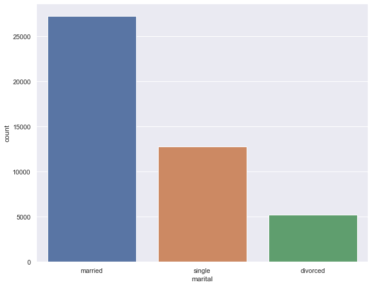

```python
# plotting the countplot for marital status

plt.figure(figsize=(10,8))
sns.countplot(dfTermDeposit['marital']);
plt.show() # observation count of married is more than single and divorced combined
```

```python
# statistics for the feature

dfTermDeposit['marital'].describe()
```

```
count       45211
unique          3
top       married
freq        27214
Name: marital, dtype: object
```

**1.1.7 Education level**

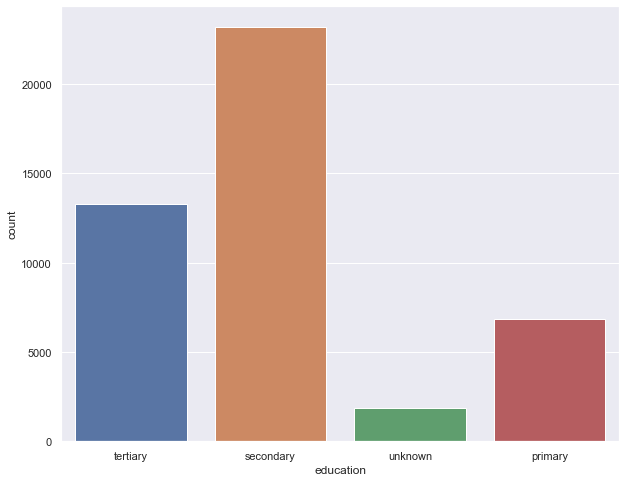

```python
# count plot for education

plt.figure(figsize=(10,8))
sns.countplot(dfTermDeposit['education']);
plt.show() # there are clearly more observations with secondary education level
```

```python
# statistics for the feature

dfTermDeposit['education'].describe()
```

```
count         45211
unique            4
top       secondary
freq          23202
Name: education, dtype: object
```

**1.1.8 Default in credit**

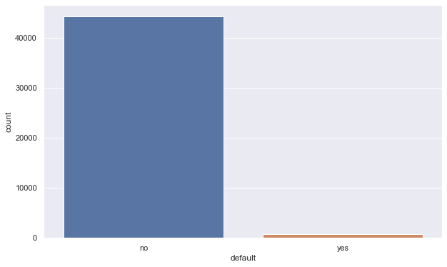

```python
# count plot for default in credit

plt.figure(figsize=(10,6))
sns.countplot(dfTermDeposit['default']);
plt.show() # very few observations have credit as default
```

```python
# statistics for the feature

dfTermDeposit['default'].describe()
```

```
count     45211
unique        2
top          no
freq      44396
Name: default, dtype: object
```

```python
# finding the percentage of observations with default in credit

dfTermDeposit['default'].value_counts(normalize=True) # about 2% have credit in default
```

```
no     0.981973
yes    0.018027
Name: default, dtype: float64
```

**1.1.9 Housing Loan**

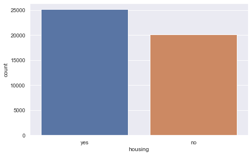

```python
# plotting the count plot for observations having housing loan

plt.figure(figsize=(8,5))
sns.countplot(dfTermDeposit['housing']);
plt.show() # the distribution is an even distribution
```

```python
# statistics for the feature

dfTermDeposit['housing'].describe()
```

```
count     45211
unique        2
top         yes
freq      25130
Name: housing, dtype: object
```

```python
# finding the percentage of observations with housing loan

dfTermDeposit['housing'].value_counts(normalize=True) # about 55% have housing loan
```

[output not shown]

**1.1.10 Personal Loan**

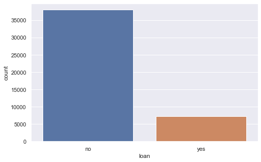

```python
# count plot for observations having personal loan

plt.figure(figsize=(8,5))
sns.countplot(dfTermDeposit['loan']);
plt.show()
```

```python
# statistics for the feature

dfTermDeposit['loan'].describe()
```

```
count     45211
unique        2
top          no
freq      37967
Name: loan, dtype: object
```

**1.1.11 Balance in Account**

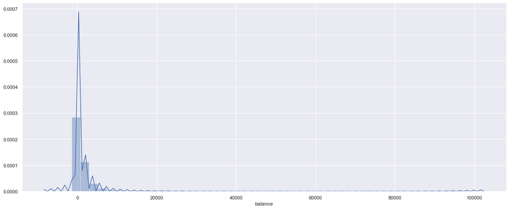

```python
# plot histogram for balance

plt.figure(figsize = (20,8))
sns.distplot(dfTermDeposit['balance'],kde=True);
plt.show() # the plot is right skewed with negative vlaues
```

```python
# statistics for the feature

dfTermDeposit['balance'].describe()
```

```
count     45211.000000
mean       1362.272058
std        3044.765829
min       -8019.000000
25%          72.000000
50%         448.000000
75%        1428.000000
max      102127.000000
Name: balance, dtype: float64
```

**1.1.12 Contact**

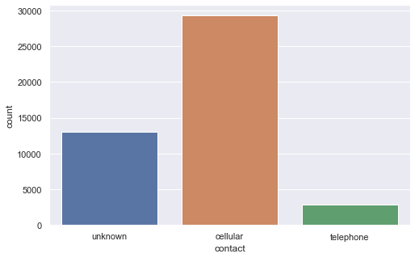

```python
# count plot for contact communication type

plt.figure(figsize=(8,5))
sns.countplot(dfTermDeposit['contact']);
plt.show() # more people prefer cellular for contact.
```

```python
# statistics for the feature

dfTermDeposit['contact'].describe()
```

```
count        45211
unique           3
top       cellular
freq         29285
Name: contact, dtype: object
```

**1.1.13 Month**

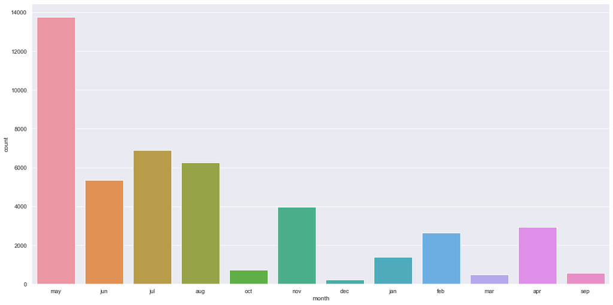

```python
# count plot for last contact month of year

plt.figure(figsize=(20,10))
sns.countplot(dfTermDeposit['month']);
plt.show() # most contacts were made in May, June, July and August
```

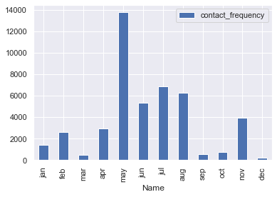

```python
# plotting the frequency of contacts per month in ascending order

dfMonths = pd.DataFrame(dfTermDeposit['month'].value_counts())

dfMonths['new_index'] = pd.Series({'jan':0,'feb':1,'mar':2,'apr':3,'may':4,'jun':5,
                                   'jul':6,'aug':7,'sep':8,'oct':9,'nov':10,'dec':11})

dfMonths.reset_index(inplace=True)

dfMonths.rename(columns={'index':'Name','month':'contact_frequency','new_index':'Month'}, inplace=True)

dfMonths.set_index('Month', inplace=True)


dfMonths[['contact_frequency','Name']].sort_index().plot(kind='bar', x='Name')
plt.show();
```

```python
# statistics for the feature

dfTermDeposit['month'].describe()
```

```
count     45211
unique       12
top         may
freq      13766
Name: month, dtype: object
```

**1.1.14 Day**

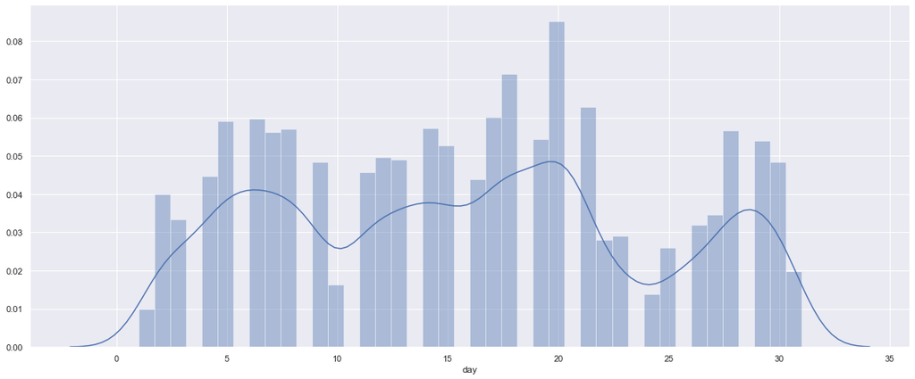

```python
# histogram of last contact day of the month

plt.figure(figsize = (20,8))
sns.distplot(dfTermDeposit['day'],kde=True);
plt.show()
```

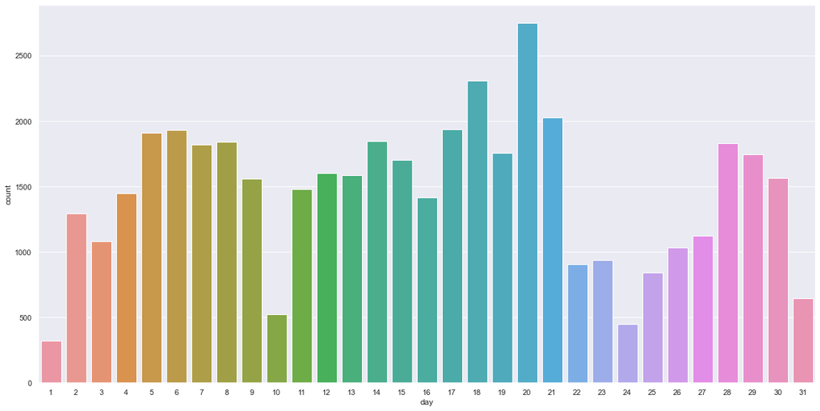

```python
# count plot for last contact day of the month

plt.figure(figsize=(20,10))
sns.countplot(dfTermDeposit['day']);
plt.show() # indicates that more calls were made between 11-21, middle of the month
```

```python
# statistics for the feature

dfTermDeposit['day'].describe()
```

```
count    45211.000000
mean        15.806419
std          8.322476
min          1.000000
25%          8.000000
50%         16.000000
75%         21.000000
max         31.000000
Name: day, dtype: float64
```

**1.1.15 Duration**

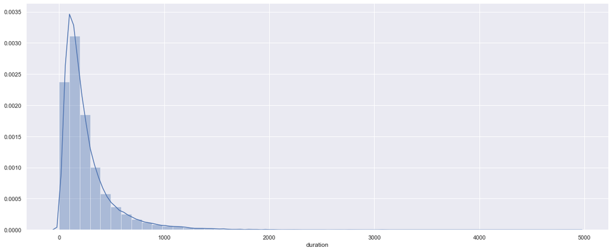

```python
# histogram of the last contact duration

plt.figure(figsize = (20,8))
sns.distplot(dfTermDeposit['duration'],kde=True);
plt.show() # plot indicates a right skewed plot
```

```python
# statistics for the feature

dfTermDeposit['duration'].describe()
```

```
count    45211.000000
mean       258.163080
std        257.527812
min          0.000000
25%        103.000000
50%        180.000000
75%        319.000000
max       4918.000000
Name: duration, dtype: float64
```

**1.1.16 Campaign**

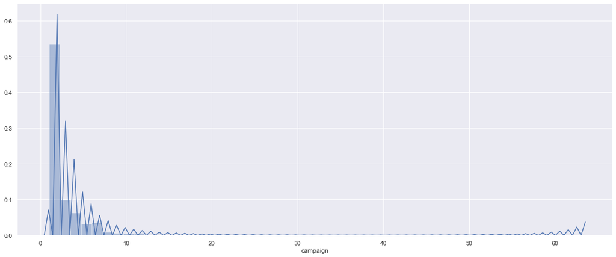

```python
# histogram of number of contacts performed during this campaign and for this client

plt.figure(figsize = (20,8))
sns.distplot(dfTermDeposit['campaign'],kde=True);
plt.show() # plot shows a right skewed dataset.
```

```python
# statistics for the feature

dfTermDeposit['campaign'].describe()
```

```
count    45211.000000
mean         2.763841
std          3.098021
min          1.000000
25%          1.000000
50%          2.000000
75%          3.000000
max         63.000000
Name: campaign, dtype: float64
```

**1.1.17 Pdays**

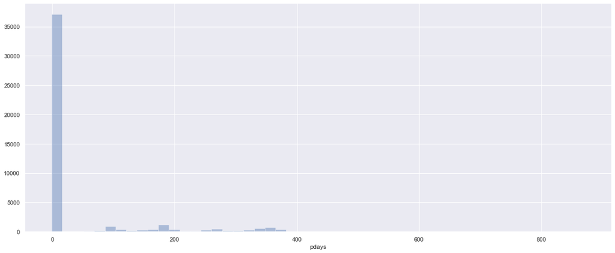

```python
# histogram to plot number of days that passed by after the client was last contacted

plt.figure(figsize = (20,8))
sns.distplot(dfTermDeposit['pdays'],kde=False);
plt.show() # the plot shows that maximum observations were never contacted or contact period was >900 days
```

```python
# statistics for the feature

dfTermDeposit['pdays'].describe()
```

```
count    45211.000000
mean        40.197828
std        100.128746
min         -1.000000
25%         -1.000000
50%         -1.000000
75%         -1.000000
max        871.000000
Name: pdays, dtype: float64
```

**1.1.18 Previous**

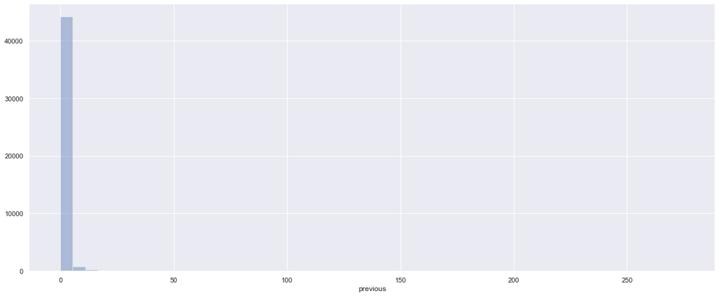

```python
# distplot for contacts performed before this campaign and for this client

plt.figure(figsize = (20,8))
sns.distplot(dfTermDeposit['previous'],kde=False);
plt.show() # shows that majority of clients were not contacted
```

```python
# statistics for the feature

dfTermDeposit['previous'].describe()
```

```
count    45211.000000
mean         0.580323
std          2.303441
min          0.000000
25%          0.000000
50%          0.000000
75%          0.000000
max        275.000000
Name: previous, dtype: float64
```

**1.1.19 Poutcome**

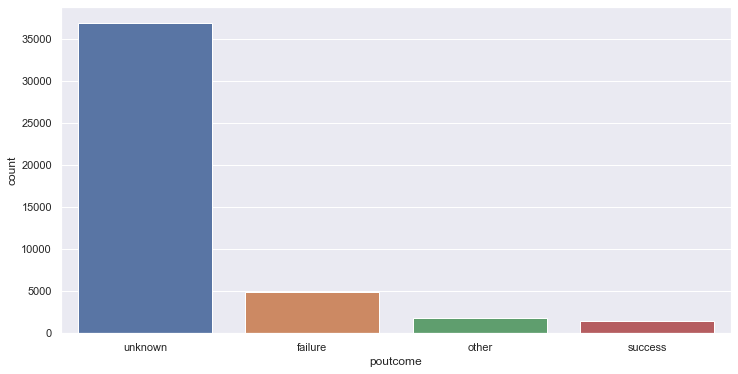

```python
# count plot for outcome of the previous marketing campaign

plt.figure(figsize=(12,6))
sns.countplot(dfTermDeposit['poutcome']);
plt.show()
```

```python
# statistics for the feature

dfTermDeposit['poutcome'].describe()
```

```
count       45211
unique          4
top       unknown
freq        36959
Name: poutcome, dtype: object
```

**1.1.20 Target**

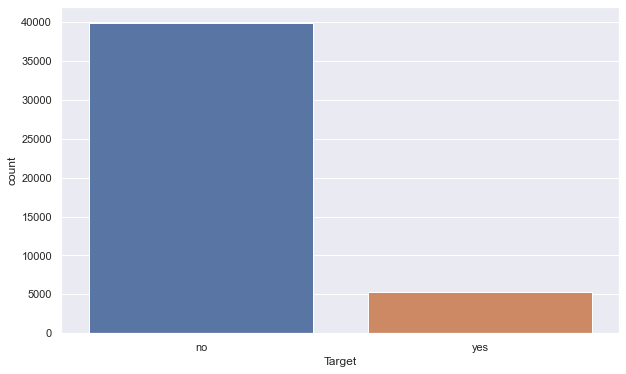

```python
# count plot of the clients who subscribed to term deposit

plt.figure(figsize=(10,6))
sns.countplot(dfTermDeposit['Target']);
plt.show()
```

```python
# percentage classes of dependent variable

dfTermDeposit['Target'].value_counts(normalize=True)
```

```
no     0.883015
yes    0.116985
Name: Target, dtype: float64
```

**The resulting data model is a imbalanced data set with class-1 at 12% and class-0 at 88%. Analysis must be done to improve the data model balance and see if class-1 % can be imporved.**

### 1.1.2 Data pollution, outlier’s treatment and missing values treatment

1. There are 10 columns which are of string/object data type which need to be converted to categorical or other data types
2. Most columns are right skewed with Balance,campaign,pdays and Duration being skewed. Previous is heavily skewed. Scaling and Normalization may be considered on these columns
3. The data set has a mix of ordinal, nominal and binary categoricals.
4. Imputation must be performed to change binary to boolean. Ordinals must be replaced with sequential order. Nominal categoricals should be exposed to one hot encoding.
5. There are no missing values and no NA or NaN values. Also, there are no duplicate rows.
6. Balance and pdays have -ve values which can be corrected by **binning**
7. Dependent variable 'Target' denotes a imbalance dataset. Operation must be performed to balance the data set or right model should be selected.

### 1.1.3 Univariate analysis insight from plots

1. Histogram of age shows that it is slightly right skewed
2. Count plot for job shows that most observations are in Management, Technician and Blue-collar categorical values
3. Count plot of marital status shows that observations with married categorical value outweigh single and divorced combined
4. Count plot of education shows that most observations have secondary and tertiary education level
5. Count plot of credit default shows that there are less than 2% defaulters
6. Count plot of housing loan shows that the dataset is divided 55% with housing loan
7. Count plot of personal loan shows that few people in the observation set have personal loan
8. Histogram for balance shows that it is heavily skewed with 7280 observations with less than or equal to 0 balance
9. Most people have their contact as cellular
10. Statistically most calls were made in the middle of the year with bulk being in the months of May, June, July and August
11. Calls are fairly distributed over all the days of the month with most calls being made between 11-21
12. Duration shows a heavy skewness
13. Histogram for number of contacts performed during this campaign and for this client shows heavy skewness
14. Plot for Pdays shows that majority of the observations fall under either no contact or contact greater than 900 days
15. Distplot for contacts performed before this campaign and for this client indicated that majority of the clients were not contacted.
16. Count plot for poutcome shows that people who were not contacted or contact greater than 900, fall in categorical value unknow. This value is 36959
17. The data set is a heavily imbalanced set.

### 1.2. Multivariate analysis (8 marks)

a. Bi-variate analysis between the predictor variables and target column. Comment on your findings in terms of their relationship and degree of relation if any. Visualize the analysis using boxplots and pair plots, histograms or density curves. Select the most appropriate attributes.  
b. Please provide comments in jupyter notebook regarding the steps you take and insights drawn from the plots

**NOTE: The below plotting is being made after converting binary categorical to boolean(0,1)**

**1.2.1 Age vs Target**

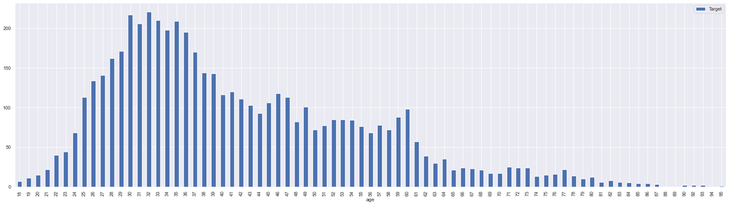

```python
# count of people subscribing to term deposit grouped by age

dfTermDeposit.groupby(by=['age'])['Target'].sum().reset_index().plot(x='age',y='Target',kind='bar',
                                                                           figsize=(30,8));
plt.show()
```

**1.2.2 Job vs Target**

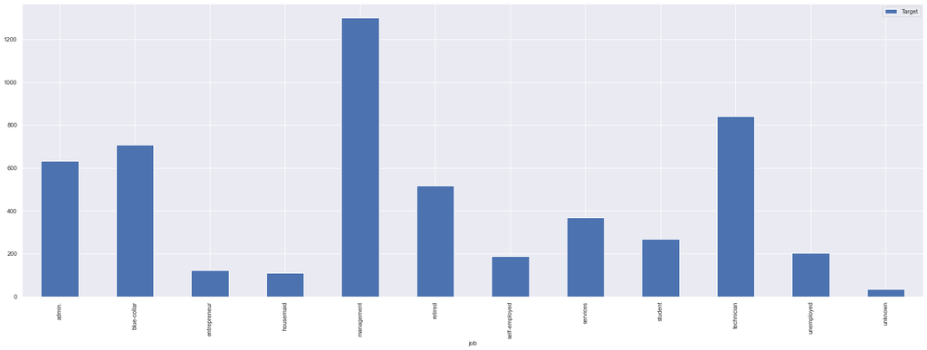

```python
# count of people subscribing to term deposit grouped by job

dfTermDeposit.groupby(by=['job'])['Target'].sum().reset_index().plot(x='job',y='Target',kind='bar',
                                                                           figsize=(30,10));
plt.show()
```

**1.2.3 Martial vs Target**

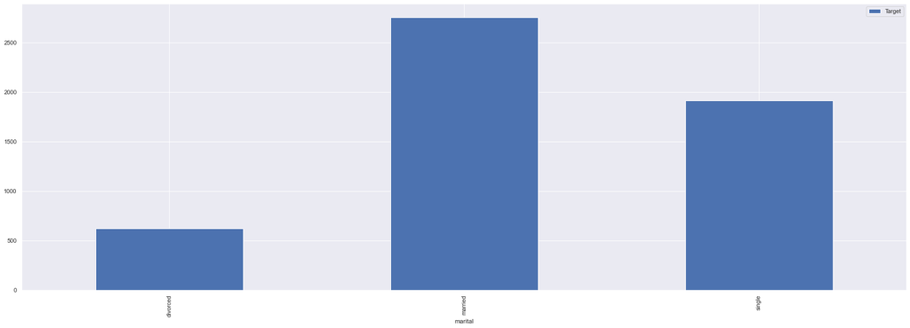

```python
# count of people subscribing to term deposit grouped by marital status

dfTermDeposit.groupby(by=['marital'])['Target'].sum().reset_index().plot(x='marital',y='Target',kind='bar',
                                                                           figsize=(30,10));
plt.show()
```

**1.2.4 Education vs Target**

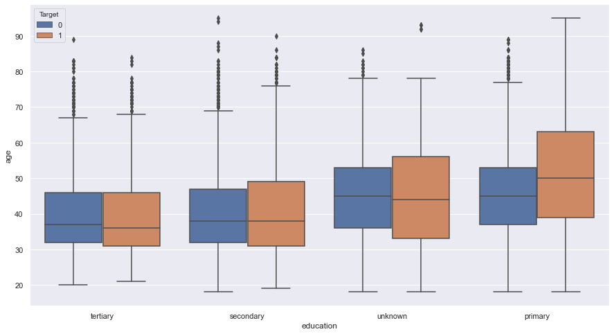

```python
# boxplot between age and education based on Target

plt.figure(figsize=(15,8))
sns.boxplot(x='education',y='age', data=dfTermDeposit, hue='Target');
plt.show() # several outliers are show in data for secondary and tertiary categorical values
```

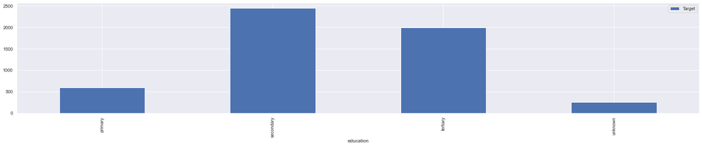

```python
# count of people subscribing to term deposit grouped by education

dfTermDeposit.groupby(by=['education'])['Target'].sum().reset_index().plot(x='education',y='Target',kind='bar',
                                                                           figsize=(30,5));
plt.show()
```

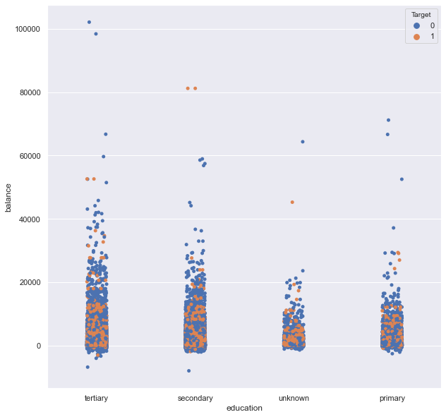

```python
# strip plot between education, balance with hue Target

plt.figure(figsize=(10,10))
sns.stripplot(dfTermDeposit['education'],dfTermDeposit['balance'], hue = dfTermDeposit['Target'], jitter=True);
plt.show()
```

**1.2.5 default vs Target**

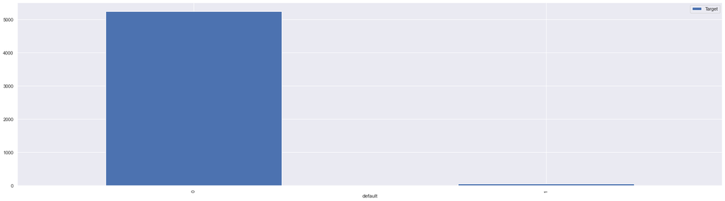

```python
# count of people subscribing to term deposit grouped by credit default

dfTermDeposit.groupby(by=['default'])['Target'].sum().reset_index().plot(x='default',y='Target',kind='bar',
                                                                           figsize=(30,8));
plt.show()
```

**1.2.6 Housing vs Target**

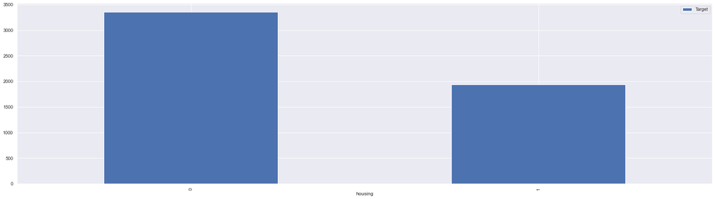

```python
# count of people subscribing to term deposit grouped by housing loan

dfTermDeposit.groupby(by=['housing'])['Target'].sum().reset_index().plot(x='housing',y='Target',kind='bar',
                                                                           figsize=(30,8));
plt.show()
```

**1.2.7 loan vs Target**

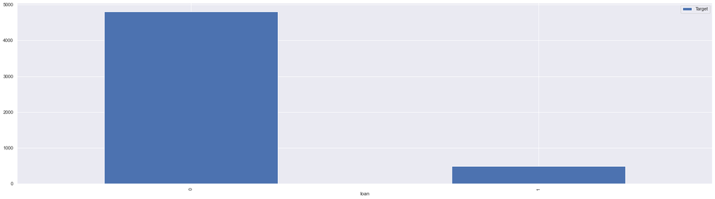

```python
# count of people subscribing to term deposit grouped by personal loan

dfTermDeposit.groupby(by=['loan'])['Target'].sum().reset_index().plot(x='loan',y='Target',kind='bar',
                                                                           figsize=(30,8));
plt.show()
```

**1.2.8 Balance vs Target**

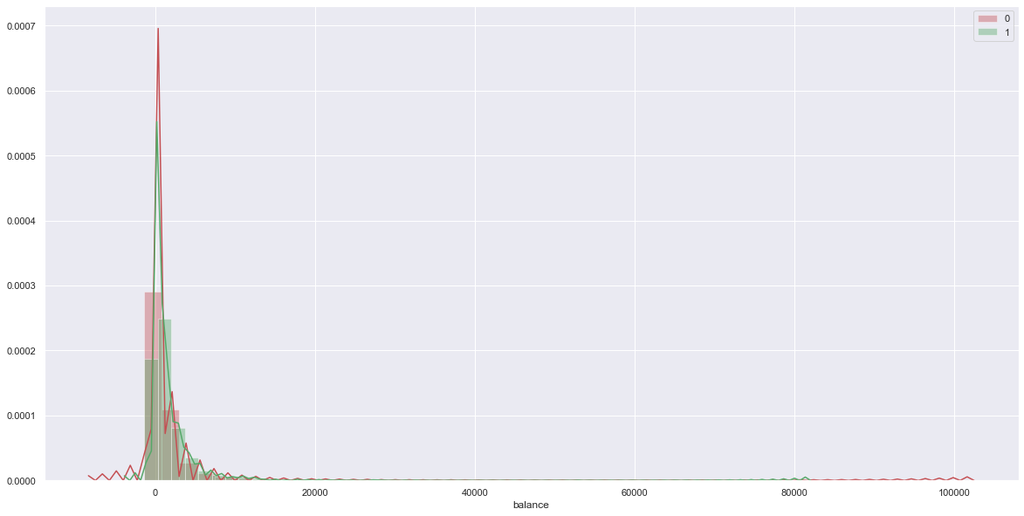

```python
# histogram between balance and Target

plt.figure(figsize = (20,10))
sns.distplot(dfTermDeposit[dfTermDeposit['Target']==0]['balance'],color='r', label=0)
sns.distplot(dfTermDeposit[dfTermDeposit['Target']==1]['balance'],color='g', label=1)
plt.legend()
plt.show()
```